# PAS Ultimate

### Kdy použít jakou transformaci

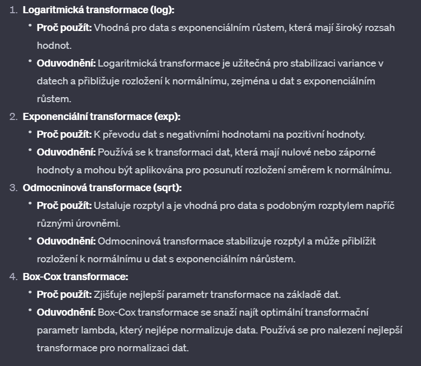

## Hodina 7 a 8 je v souboru “Pravděpodobnost”

Hodina 9 nebyla.

## Hodina 10

```r
library(fitdistrplus)
library(DescTools)

# Nactete databazi Stulong.RData
names(Stulong)<-c("ID","vyska","vaha","syst1","syst2","chlst","vino","cukr","bmi",
                  "vek","KOURrisk","Skupina","VekK")
```

### Odhad rozdělení

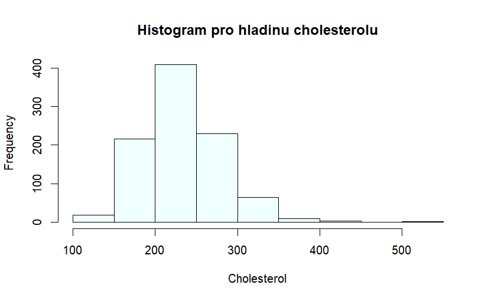

```r
## Jake rozdeleni ma cholesterol?
prom1<-Stulong$chlst
hist(prom1,col="azure",main="Histogram pro hladinu cholesterolu",xlab="Cholesterol")
```

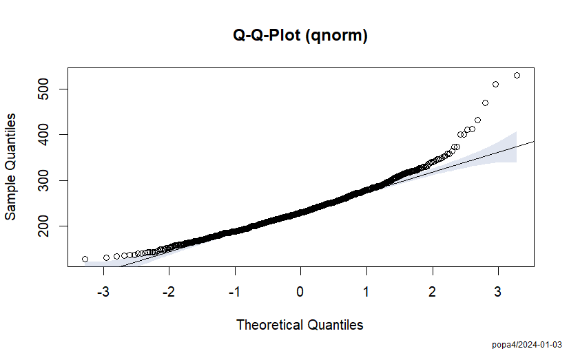

```r
PlotQQ(prom1)
```

```r
Skew(prom1)
```

```
[1] 1.006148
```

```r
Kurt(prom1)
```

```
[1] 3.152846
```

```
summary statistics
------
min:  128   max:  530
median:  230
mean:  234.7966
estimated sd:  48.21844
estimated skewness:  1.00932
estimated kurtosis:  6.188736
```

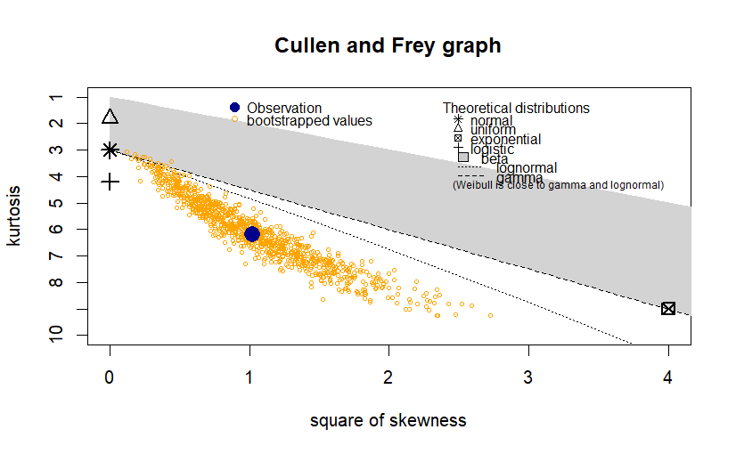

```r
# Pomer sikmosti a spicatosti, k jakemu rozdeleni mam nejblize
descdist(prom1,discrete=FALSE,boot=1000)
```

```r
# zkusim normalni, logisticke a lognormalni
(fit1<-fitdist(prom1,"norm"))
```

```
Fitting of the distribution ' norm ' by maximum likelihood
Parameters:
```

|  | estimate | Std. Error |
| --- | --- | --- |
| mean | 234.79665 | 1.560311 |
| sd | 48.19317 | 1.103307 |

```r
(fit2<-fitdist (prom1,"logis"))
```

```
Fitting of the distribution ' logis ' by maximum likelihood
Parameters:
```

|  | estimate | Std. Error |
| --- | --- | --- |
| location | 232.03274 | 1.4773537 |
| scale | 26.27792 | 0.7086758 |

```r
(fit3<-fitdist (prom1,"lnorm"))
```

```
Fitting of the distribution ' lnorm ' by maximum likelihood
Parameters:
```

|  | estimate | Std. Error |
| --- | --- | --- |
| meanlog | 5.4386841 | 0.006448211 |
| sdlog | 0.1991652 | 0.004559056 |

```r
# porovnani pomoci AIC a BIC kriterii -> nejlepší model je ten co má nejmenší hodnoty
data.frame(distr=c("Norm","Logis","Lognorm"),
           AIC=c(fit1$aic,fit2$aic,fit3$aic),
           BIC=c(fit1$bic,fit2$bic,fit3$bic)
)
```

| distr | AIC | BIC |
| --- | --- | --- |
| Norm | 10105.25 | 10114.97 |
| Logis | 10054.24 | 10063.96 |
| Lognorm | 10009.56 | 10019.28 |

```r
  # nejnizsi hodnoty AIC i BIC ma lognormalni rozdeleni
```

#### 95%-ní interval spolehlivosti

- Jedná se o rozmezí hodnot, ve kterém s 95% jistotou leží skutečná hodnota parametru populace, pokud máme pouze vzorek dat.

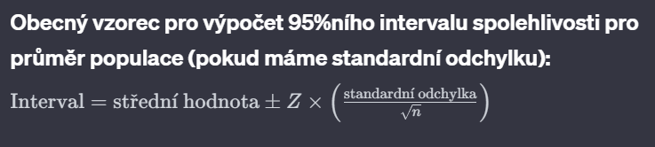

- Ukázka:
  - **`coef(fit3)`** vrací odhady koeficientů (parametrů) modelu.
  - **`fit3$sd`** obsahuje odhady standardních odchylek těchto koeficientů.
  - Výpočet **`coef(fit3)-1.96*fit3$sd`** a **`coef(fit3)+1.96*fit3$sd`** používá 1.96 jako hodnotu z-score pro 95% interval spolehlivosti, aby vytvořil dolní a horní hranice intervalu.

```r
# 95%-ni intervaly spolehlivosti pro odhady parametru lognormalniho rozdeleni
data.frame(Odhad=coef(fit3),
           Spodek_95ni=coef(fit3)-1.96*fit3$sd,
           rsek_95ni=coef(fit3)+1.96*fit3$sd
)
```

|  | Odhad | Spodek_95ni | rsek_95ni |
| --- | --- | --- | --- |
| meanlog | 5.4386841 | 5.4260456 | 5.4513226 |
| sdlog | 0.1991652 | 0.1902294 | 0.2081009 |

```r
#Jde
```

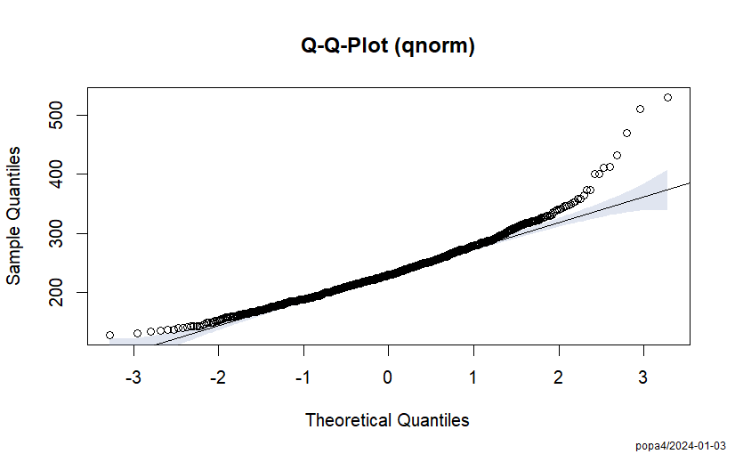

```r
# kontrola, jak jednotlivym rozdelenim sedi Q-Q plot
#to co nejvíc sedí na tý čáře je nejlepší
PlotQQ(prom1)
```

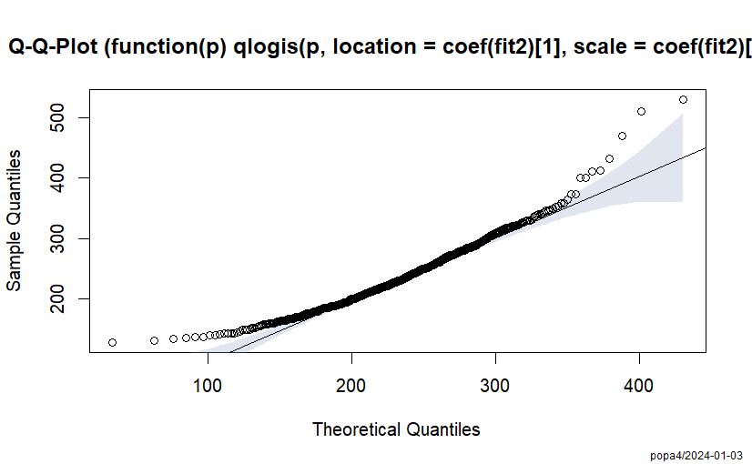

```r
PlotQQ(prom1,qdist=function(p) qlogis(p,location=coef(fit2)[1],scale=coef(fit2)[2]))
```

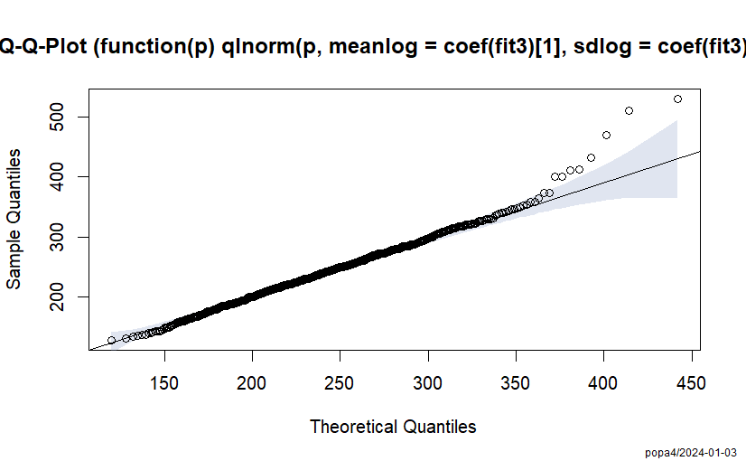

```r
PlotQQ(prom1,qdist=function(p) qlnorm(p,meanlog=coef(fit3)[1],sdlog=coef(fit3)[2]))
```

```r
  # lognormalni rozdeleni sedi nejlepe
```

```r
#Tohle je celý zakomentěný protože to nevím proč háže v sešitě chyby který to normálně nedělá :)


## Jakym rozdelenim se ridi cukr?
#prom1<-Stulong$cukr
#hist(prom1)
#tady koukam ktery rozdělení je nejlepší (na čem leží většina bootstrapůs)
#descdist(prom1,discrete=FALSE,boot=1000) # kdybycht odělal ro diskrenti rozdeleni tak discrete = TRUE
#(fit0<-fitdist(prom1, "lnorm"))# i když na to ukazuje ta věc nad tím tak tohle nejde protože musí být ostře kladný hodnoty (bez nul) a ten cukr má nuly
#(fit00<-fitdist(prom1, "gamma"))#to samé tady
#(fit1<-fitdist(prom1, "norm"))
#(fit2<-fitdist(prom1, "logis"))
#(fit3<-fitdist(prom1, "exp"))
#(fit4<-fitdist(prom1, "beta"))#musí but [0-1] takže nou
#(fit5<-fitdist(prom1+0.000001, "lnorm"))# případný fix -> ale ne v testu, v testu vybrat jiný
#(fit6<-fitdist(prom1+0.000001, "gamma"))# případný fix -> ale ne v testu, v testu vybrat jiný

#data.frame(distr=c("norm", "logis", "exp", "lnorm", "gamma"),
#           AIC=c(fit1$aic,fit2$aic,fit3$aic,fit5$aic,fit6$aic),
#           BIC=c(fit1$bic,fit2$bic,fit3$bic,fit5$bic,fit6$bic)
#)
#PlotQQ(prom1)
```

#### Interval spolehlivosti po druhé

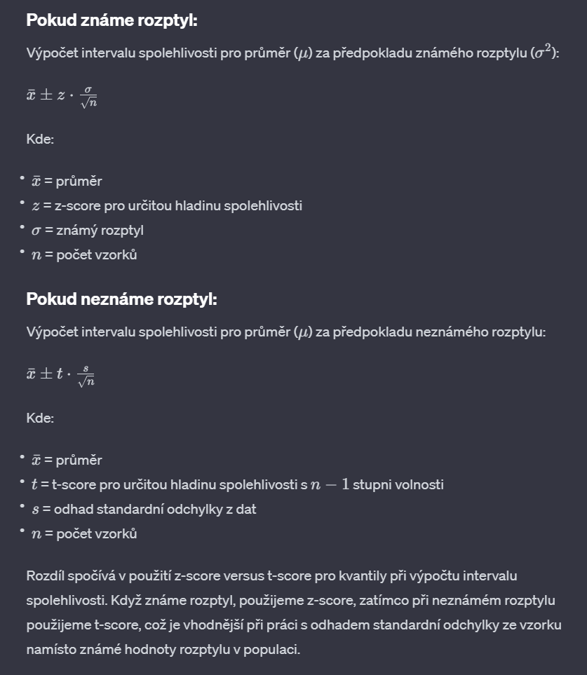

```r
# Nactete data Policie.RData
## Spoctete 95% interval spolehlivosti pro prumer vysky kdyz vite,
#  ze rozptyl vysky dospelych muzu je 49.
prom2<-Policie$height

# Známý rozptyl
mn <- mean(prom2)  # Výpočet průměru
sd_known <- sqrt(49)  # Známý rozptyl výšky dospělých mužů
n <- length(prom2)  # Počet vzorků
alpha <- 0.05  # Hladina významnosti

# Výpočet kvantilu normálního rozdělení pro zadanou hladinu významnosti
q_n <- qnorm(1 - alpha / 2)

# Dolní mez intervalu spolehlivosti
(lower_known <- mn - q_n * sd_known / sqrt(n))
```

```
[1] 176.3397
```

```r
# Horní mez intervalu spolehlivosti
(upper_known <- mn + q_n * sd_known / sqrt(n))
```

```
[1] 180.2203
```

```r
# Neznámý rozptyl
mn <- mean(prom2)  # Výpočet průměru
sd_unknown <- sd(prom2)  # Odhad standardní odchylky z dat
n <- length(prom2)  # Počet vzorků
alpha <- 0.05  # Hladina významnosti

# Výpočet kvantilu Studentova t-rozdělení pro zadanou hladinu významnosti a stupně volnosti
q_t <- qt(1 - alpha / 2, n - 1)

# Dolní mez intervalu spolehlivosti
(lower_unknown <- mn - q_t * sd_unknown / sqrt(n))
```

```
[1] 176.24
```

```r
# Horní mez intervalu spolehlivosti
(upper_unknown <- mn + q_t * sd_unknown / sqrt(n))
```

```
[1] 180.32
```

#### Pomocí Bootstrapu

- **Bootstrapping:**
  - **Vzorkování s nahrazením:** Z původního datasetu o velikosti n se opakovaně a náhodně vybírají vzorky o stejné velikosti n.
  - **Vytvoření bootstrap vzorků:** Tyto vzorky se vytvářejí z náhodného výběru s nahrazením z původního datasetu. To znamená, že každý prvek může být vybrán vícekrát nebo vůbec.
- **Výpočet statistiky z bootstrap vzorků:**
  - Z každého z těchto bootstrap vzorků se vypočítá statistika zájmu, například průměr, medián, rozptyl atd.
  - V tomto případě se počítá průměr z každého z bootstrapped vzorků.
- **Interval spolehlivosti:**
  - Po vytvoření mnoha bootstrap vzorků se provede analýza rozdělení vypočtených statistik (v tomto případě průměrů).
  - Pro výpočet intervalu spolehlivosti se využívají kvantily rozdělení těchto statistik.
  - Často se používá percentilová metoda pro výpočet intervalů spolehlivosti, kde se určí dolní a horní kvantil pro požadovanou hladinu spolehlivosti (například 95 %).

```r
#A jak spocitat interval spolehlivosti pro stredni hodnotu reakcni doby
#  pomoci bootstrapu?
prom3<-Policie$react
# Počet bootstrap vzorků
n_boot <- 1000

# Prázdný vektor pro ukládání průměrů bootstrap vzorků
bootstrap_means <- numeric(n_boot)

# Počet dat
n <- length(prom3)

# Cyklus pro generování bootstrap vzorků a výpočet průměrů
for (i in 1:n_boot) {
    # Náhodný výběr s nahrazením ze vstupních dat
    bootstrap_sample <- sample(prom3, replace = TRUE)

    # Výpočet průměru bootstrap vzorku
    bootstrap_means[i] <- mean(bootstrap_sample)
}

# Výpočet percentilů pro vytvoření intervalu spolehlivosti
lower_percentile <- quantile(bootstrap_means, 0.025)  # Dolní mez 95% intervalu
upper_percentile <- quantile(bootstrap_means, 0.975)  # Horní mez 95% intervalu

# Výsledný interval spolehlivosti pro střední hodnotu reakční doby
confidence_interval <- c(lower_percentile, upper_percentile)

confidence_interval
```

```
   2.5%   97.5%
0.27779 0.34720
```

```r
# Pomoci funkce
MeanCI(prom3,method="boot")
```

```
  mean lwr.ci upr.ci
0.3134 0.2794 0.3476
```

```r
BootCI(prom3,FUN = mean)
```

```
     mean    lwr.ci    upr.ci
0.3134000 0.2790164 0.3477920
```

```r
  # pomoci parametru FUN mohu pocitat interval spolehlivosti pro libovolnou funkci
  decil <- function(x) quantile(x,0.1)
  BootCI(prom3,FUN = decil)
```

```
    decil    lwr.ci    upr.ci
0.1770000 0.1322975 0.2301409
```

```r
    # bootstrapovy interval spolehlivosti pro dolni decil
```